# Part-I Summer Project

# Part-I Summer Project

| **Deadline:** | **17:00 Friday (8th of May) End of Week 23** |
| --- | --- |
| **Assessment Mode:** | **IN LAB DEMO IN YOUR WEEK 24 LAB SESSION** |
|  | [MOODLE SUBMISSION](https://modules.lancaster.ac.uk/course/section.php?id=487761) |
|  | [REPOSITORY LINK SUBMISSION](https://forms.cloud.microsoft/Pages/ResponsePage.aspx?id=Ec2bnHqXnE6poLxzQJAWSiBBU6UiHFpGmj6rRi0EHmRUOUpGNFdPOVNQVTZPSzg4NTVXVjI4Vkg1Qy4u) |

## Aims

In this final term of your first year, there is a single task: a single cross-module project that is designed to bring together all you have learned since you joined us in October. This project represents the final piece of practical coursework for your first year and constitutes **33%** of the coursework assessment for the year. **Time to show us what you can do!**

You have a *choice* of projects to undertake from the choices below. You need to **pick just one** of these projects. Read each of them carefully before choosing which project to undertake. Please note that the projects state which programming language you **must** use for that project. These projects have been designed to build on what you have learned in SCC.111, SCC.121 and SCC.131 (where applicable). Note that some projects are unavailable / have different requirements for students not studying SCC.131 (such as those studying for Computer Science and Mathematics or Management and IT degrees).

## Getting Support

You should attend your timetabled SCC1x1 lab session **in weeks 21-23** inclusive for support, where staff and teaching assistants will be present to provide guidance, feedback and to answer your questions. **Please note that your week 24 session will be reserved for you to demonstrate the functionality of your work**. **Staff will not be able to provide support during the Week 24 lab session.**

The FAST hub will also be available daily if you need additional drop-in support. *See Moodle for more details.*

## Submission and Assessment

This work will be assessed by a member of academic staff after you follow the instructions below to submit your work. This assessment will be further informed by a practical demonstration of your work. You will be asked to present your work in your Week 24 lab session. Be prepared to take the lead in demonstrating your project, and to answer questions about it.

- You MUST submit your code to Moodle by the advertised deadline in a .zip file.
- You MUST demonstrate your work by downloading your Moodle submission and running it IN YOUR OWN WEEK 24 TIMETABLED LAB SESSION.
- You MUST ensure that your project can be compiled and executed FROM THE COMMAND LINE ON A LAB PC, without using an IDE. (If the project you selected has further instructions on how to compile and run your project, you must follow them.)
- The standard University regulation on permitting late submission of coursework DOES NOT APPLY TO THIS COURSEWORK ASSIGNMENT.

**FAILURE TO ADHERE TO THE ABOVE WILL RESULT IN A FAIL MARK (F4) BEING RECORDED.**

## Version Control Submission

You **are expected** to use git version control for your project, and this is reflected in the marking scheme. To submit your private Github repository for assessment, you must do the following:

1. Regardless of the project you select, invite the ‘scc111-2026’ github user as a collaborator, as shown in the lectures slides.
2. **Submit the FULL URL of your project repository (the same link that you’d need to ‘clone’ it) using the form linked at the top of this page.**

## Marking Scheme

Your work will be marked based on the following categories. Your final grade will be determined based on a weighted mean of these grades according to the weighting shown in the table below.

Marking Scheme

**Project Functionality**

- See individual project descriptions below for indicative levels of the functionality required.

**70%**

**Code Structure and Elegance**

- Modularity of code
- Use of appropriate data types and libraries
- Use of appropriate language constructs (arrays, loops, functions, methods, classes)

**10%**

**Code Style**

- Appropriate comments, code indentation
- Appropriate name/ scope of variables and functions/methods

**10%**

**Use of Git version control**

- Clean and regular commits
- Appropriate commit messages

**10%**

In all cases a grade descriptor (A, B, C, D, F) will be used to mark your work in each category. The following sections provide an indication of the level of functionality expected.

Students may also award of a distinction (+) category overall if they feel a piece of work exhibits clearly outstanding practice. If you feel your work warrants a distinction for going significantly above and beyond the specification, **it is your responsibility to state and demonstrate this during your Week 24 lab session**.

## Plagiarism

This project **should be entirely your own work**. In this context, that means that it is reasonable to discuss ideas with others, but you should not expect to study the code of another student, or to let them study yours. Code examples taken from the lecture notes are acceptable, as well as, **small** sections of code (a few lines, for example) from the internet - but if it is in your code, you should be able to understand and confidently explain what it does and how it works. The use of AI tools to write code on your behalf is regarded as equivalent to copying code from any external source.

## Use of AI Statement

Lancaster University has adopted a Red-Amber-Green (RAG) categorisation system to guide students on their use of Generative AI (Gen AI) tools in summative assessment. This coursework is in the **RED Category; AI tools cannot be used**. Students suspected of using AI tools in assessment identified as category red, will be investigated in line with institutional academic integrity procedures. For further information, please refer to the [AI Policy](https://www.lancaster.ac.uk/ai-policy). If you are unsure about the use of AI tools in your assessment, please consult your lab academic.

[figure not shown]

RED Category; AI tools cannot be used

# Project 1: Snow Problem! (Language: Java)

## Project Overview

Modelling simple games provide excellent challenges to test your computer programming tasks. As such, we have prepared a task for you to implement a digital version of a physical puzzle based board game called “Snow Problem” by the Happy Puzzle Company. We want to you to create a fully playable game in Java, following the object-oriented paradigm, it should be well tested, include a good user interface, and make effective use of the scalable, extensible design and version control. In other words, this will be a full work out of all the concepts you learned in last term’s SCC111 lectures.

[figure not shown]

Snow Problem

## Tasks

Your task is to develop a digital version of the game Snow Problem. Snow problem is a tile based puzzle game, based on a 5x4 grid of squares. There are four types of pieces in the game - trees, large snowballs, small snowballs and snow man heads. The game describes a number of levels (80 in total, with increasing levels of challenge), each containing up to three identical copies of each of these types of pieces. An example image of the physical game is shown below:

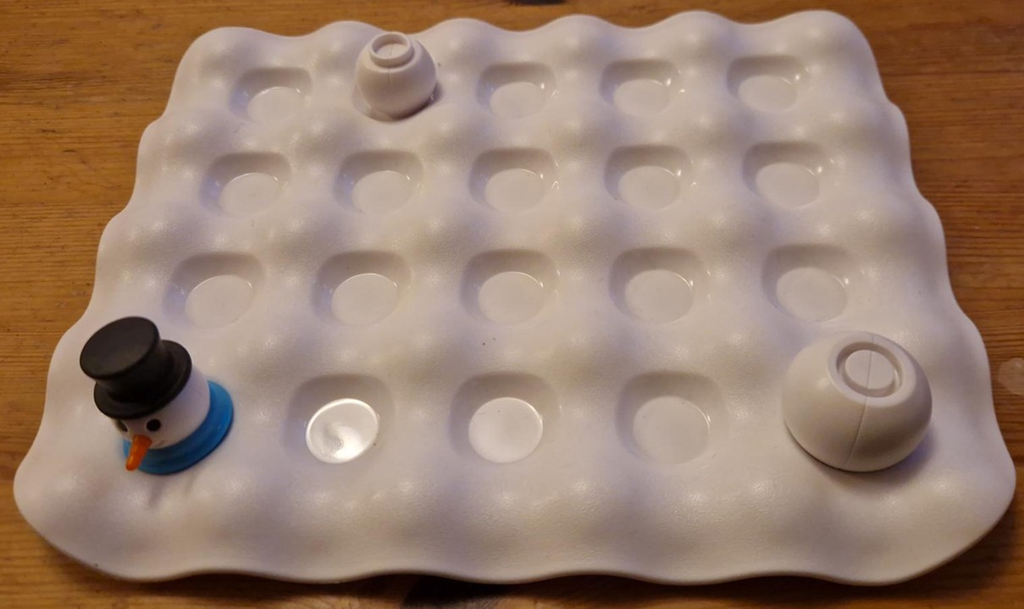

Level 1

The aim of the game is quite simple. To complete all the snowmen on the board, by stacking the snowman heads, small snowballs and large snowballs. However, there are of course rules that must be followed:

- Large and small snowballs can move horizontally or vertically across the board. Movement can however only be stopped by *any* other piece. If a snowball is moved in a direction that has no obstacle, it will fly off the end of the game board, and the game is over.
- Snowballs can be moved any number of times - as long as they stay on the gameboard.
- Trees cannot me moved.
- Small snowballs can be stacked onto an adjacent large snowball, to form a snowball stack. Once a snowball has been stacked, that stack of two snowballs CANNOT then be moved, or separated.
- A snowman’s head cannot be moved like snowballs. Snowman heads can only be stacked onto an adjacent snowball stack.
- Once all snowballs and heads have been stacked, the game has been won!

Your challenge is to implement this game in the best way you can. To help you complete the task, we have created some graphics you can use. You will find them in [in this zip file](https://livelancsac-my.sharepoint.com/:u:/g/personal/aref_lancaster_ac_uk/IQDtEwAT6PCHRKJYm7g0N8BpAVTxPjG2nxLymUHhdRQNPdQ?e=pyrA4D). Feel free to use these in your project. If you prefer to create your own graphics, you are of course free to do so.

This project is arranged as a sequence of tasks. The more tasks you complete successfully, the higher the grade you will receive. In addition, you are required to comment your work and use git version control throughout the project, as described in the lab project documentation.

Finally, please remember the you are NOT permitted to use generative AI in any software that you create. Doing so will constitute a serious case of plagiarism, and will likely result in you being referred to the Universities standing academic committee with a recommendation that you be expelled from the University. So please DO NOT do this.

### Task 1: Setting the Scene

- Create classes to represent the GameBoard.
- Using the graphics provided, create a user interface that can hold the main pieces of the game.
- Set up your game to represent level 1 of the game, as indicated by the image shown above.

### Task 2: Basic Movement

- Implement basic movement for your game, and update the screen accordingly.
- You should use mouse clicks to define which snowball to move, and its direction of travel.
- This should permit large and small snowballs to be moved around the board.
- The game should end if a snowball leaves the gameboard.
- Snowballs should obey the movement rules defined above.

### Task 3: Stacking

- Implement the rules for stacking of small on adjacent large snowballs.
- Implement the rule to permit a snowman head to be place onto a snowball stack.
- Detect the end of game when all snowmen have been fully stacked.
- Implement a total of three levels of the game, including the two outlined below.

[figure not shown]

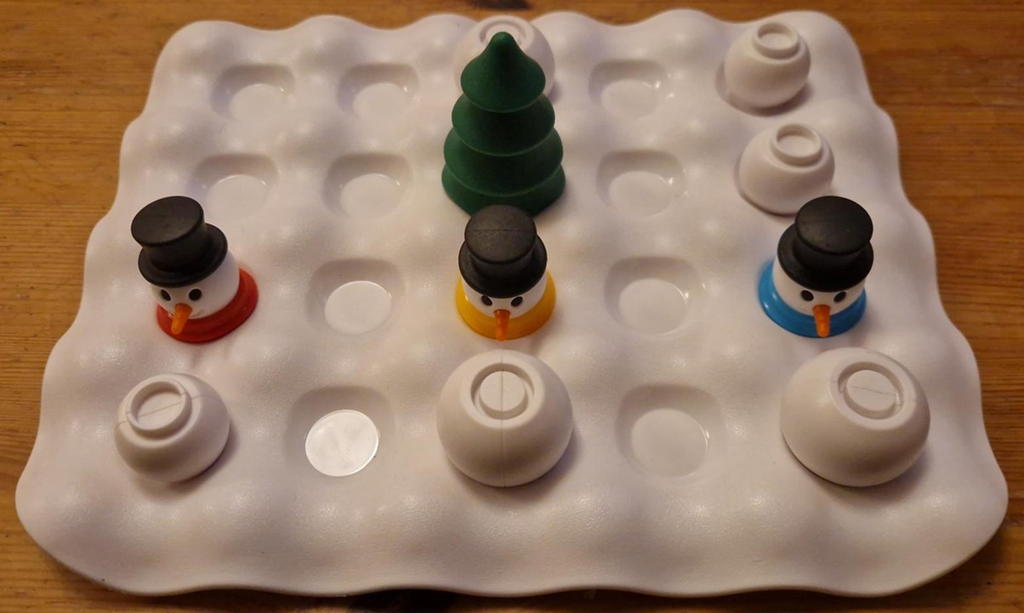

### Task 4:

- Implement all remaining game levels, as indicated in [this document](https://livelancsac-my.sharepoint.com/:b:/g/personal/aref_lancaster_ac_uk/IQDsU2NXWYIIRo_THPP1C8ZlATCX8k7WzE8t1B5F_PCM0So?e=HxpiNz).
- Pay particular attention to implementing this with elegance. Ensure you create a simple and scalable mechanism to support new levels.
- Count the number of moves taken in the game, and show this on your GUI.
- Implement a game reset option to restart a level.
- Implement a persistent (saved) high score table for each level.

### Task 5:

- Implement a puzzle solver. :)
- Probably using recursion, create a general purpose algorithm capable of solving any of the puzzles in the game. note, this is a TOUGH challenge - not for the faint of heart! To get full marks, this needs to algorithmically explore the possible moves, and identify valid solutions. Maintaining a list of the solutions won’t cut it…

## Marking Scheme

Marks will be awarded according to the marking scheme shown at the start of this document. Marks for the ‘Functionality’ section will be awarded based on individual merit, but the following table gives an **indicative** overview of the level of functionality expected for each grade band:

**SCC Major Students Studying SCC.111, SCC.121 and SCC.131**

| Grade | Description |
| --- | --- |
| A* | **Working program that meets the criteria for a A, and meets the requirements of Task 5** |
| A | **Working program that meets the criteria for a B, and meets the requirements of Task 4** |
| B | **Working program that meets the criteria for a C, and meets the requirements of Task 3** |
| C | **Working program that meets the criteria for a D, and meets the requirements of Task 2** |
| D | **Working program that meets the requirements of Task 1** |
| F | **No working program demonstrated, or program does not meet any of the requirements listed above** |

**SCC Joint Major Students Studying SCC.111 and SCC.121 only**

| Grade | Description |
| --- | --- |
| A* | **Working program that meets the criteria for a A, and meets the requirements of Task 4** |
| A | **Working program that meets the criteria for a B, and meets the requirements of Task 3** |
| B | **Working program that meets the criteria for a C, and meets the requirements of Task 2** |
| C | **Working program that meets the requirements of Task 1** |
| F | **No working program demonstrated, or program does not meet any of the requirements listed above** |

# Project 2: Journey Planner for Manchester Metrolink (Language: Java)

## Project Overview

Journey planners can be used to find the optimal route between two (or more) given locations. They are widely used to plan journeys and can be based on one, or more, modes of transport. The route may be optimised based on different criteria; for example, the journey planner may output the fastest route, the cheapest route or even the route with fewest changes depending on the user’s preferences.

For this coursework, you will develop a route planner for the Manchester Metrolink based on average journey times which are provided to you in the file [Metrolink_times_linecolour.csv](https://livelancsac-my.sharepoint.com/:x:/g/personal/aref_lancaster_ac_uk/IQDHI7wwP_CJR75CaIfnRjEvAblsiqVGnROY4sdMr9cohpw?e=M222nE). The file is divided into sections corresponding to each (color-coded) transport line of the network. Each row in a section represents a single connection between two stations on the corresponding transport line and gives the starting station, final station, and the time to travel between the stations as: From , To, Time (mins). You should assume that it takes the same time to travel in the opposite direction. An example of the information provided on journey times is given below. It says that it takes 6 mins to travel from Bury to Radcliffe on the yellow line and it takes 1 min to travel from Sale to Dane Road on the purple line.

```
From, To, Time (mins)
yellow
Bury,Radcliffe,6
purple
Brooklands,Sale,1.5
Sale,Dane Road,1
```

## Tasks

Your task is to develop a route planner for the Manchester Metrolink. An image of the network is given below for illustrative purposes only (note, not all lines are used in the provided file, and information in the file may not exactly match the figure).

[figure not shown]

Manchester metrolink route map, from https://tfgm.com/ways-to-travel/tram/network-map. Map is provided for illustrative purposes only. All of your results should be based on the information given in the provided files which may not be exactly the same as this map.

Your route planner should be based on the information and times in the provided file, not on any other timings or information. **For testing your code, we will use a new file with stations and times. The format of this file will be the same as the one given for development, but specific information on station names and times may differ.**

The program should:

- Read in information from the provided file to give station names and journey times between stations on different lines.
- Provide an interface that enables a user to specify a valid start and end station for their journey.
- Given a valid start and end station, compute a route between the two stations and output this route, including lines to travel on, journey time and changes.
- Enable users to specify constraints for optimising the journey, e.g. fewest changes, shortest time.

Full details of the expected functionality and grades are given in the task descriptions below marking.

For the provided file, an example of the shortest time journey between Salford Quays and Exchange Square, with list of all intermediate stations and any changes is given below.

```
*** Minimal Time Route ***
Salford Quays on lightblue line
Exchange Quay on lightblue line
Pomona on lightblue line
**  Change Line to red line ***
Pomona on red line
Cornbrook on red line
Deansgate/Castlefield on red line
**  Change Line to pink line ***
Deansgate/Castlefield on pink line
St. Peter's Square on pink line
Exchange Square on pink line

Overall Journey Time (mins) =  17.0
Number of Changes =  2
```

The tasks that your program must perform are detailed below. The allocation of marks for completing each of these tasks is described in the Marking Scheme.

### Task 1

- Develop a user interface that enables users to input a start and end location for their journey
- Checks if user has inputted valid station names and keep asking for user to input station names until valid ones are given

### Task 2

- Given any valid start and end location, come up with any valid route between the two locations
- Output the route with the list of intermediate stations Note: for a C you can make the simplifying assumption to treat everything as one single line, so you do not also have to output the line name here. To get higher than a C, you must include the different lines and times - e.g. as in Task 3. You do not need to complete Task 2 if you are able to complete Task 3.

An example of an expected output for the given file with start Victoria and end Old Trafford is given below. Note you can ouput any valid route for this task.

```
Victoria
Exchange Square
St. Peter's Square
Deansgate/Castlefield
Cornbrook
Trafford Bar
Old Trafford
```

### Task 3

- Give the shortest time route between a given start and end location. This should now include the fact there are different lines and you should make the simplifying assumption that changing trams takes 2 mins each time. (In case there are multiple shortest routes, you can give any.)
- Output the route with the list of intermediate stations and lines and give the overall journey time
- **Only for SCC Major Students Studying SCC.111, SCC.121 and SCC.131**: Include explicit indication of where changes are needed when the journey is output (e.g. as in the example output given above)

An example of an expected output for the given file with start start Victoria and end Old Trafford is given below **for SCC Major Students Studying SCC.111, SCC.121 and SCC.131**

```
Victoria on pink line
Exchange Square on pink line
St. Peter's Square on pink line
**  Change Line to purple line ***
St. Peter's Square on purple line
Deansgate/Castlefield on purple line
Cornbrook on purple line
Trafford Bar on purple line
Old Trafford on purple line
Overall Journey Time (mins) =  16.5
```

An example of an expected output for the given file with start start Victoria and end Old Trafford is given below for **SCC Joint Major Students Studying SCC.111 and SCC.121 only**

```
Victoria on pink line
Exchange Square on pink line
St. Peter's Square on pink line
St. Peter's Square on purple line
Deansgate/Castlefield on purple line
Cornbrook on purple line
Trafford Bar on purple line
Old Trafford on purple line
Overall Journey Time (mins) =  16.5
```

### Task 4

- Enable users to select journey constraints. Include at least the options of choosing the route with shortest time vs route with fewest changes (fewest changes route must be a Metrolink route, not a walking route).
- As well as the overall journey time, also give the total number of changes for the computed route and indicate where changes are needed when outputting the route.

An example of the expected output for the given file when the option to minimise changes is chosen with start Victoria and end Old Trafford is given below

```
*** Route with Fewest Changes ***
Victoria on green line
Shudehill on green line
Market Street on green line
St. Peter's Square on green line
Deansgate/Castlefield on green line
Cornbrook on green line
Trafford Bar on green line
Old Trafford on green line
Time (mins): 20.0
Total Changes: 0
```

### Task 5

- **Only for SCC Major Students Studying SCC.111, SCC.121 and SCC.131:**
- The user interface for inputting start and end locations as well as constraints (e.g. shortest time vs fewest changes) should be a GUI.

## Getting Started

- Refresh your knowledge of graphs, as well as the algorithms on graphs that we covered in the 121 lectures
- If you aim to implement the journey planner using a graphical interface, then refresh your knowledge of the Swing classes discussed in 111 lectures
- You may find the java collections API useful. This has a set of data structures, further details are provided here https://docs.oracle.com/javase/8/docs/technotes/guides/collections/overview.html

## Marking Scheme

Marks will be awarded according to the marking scheme shown at the start of this document. Marks for the ‘Functionality’ section will be awarded based on individual merit, but the following table gives an **indicative** overview of the level of functionality expected for each grade band:

**SCC Major Students Studying SCC.111, SCC.121 and SCC.131**

A*

**Working program that meets the criteria for a A, plus:**

- Meets the requirements of Tasks described under Star Award

A

**Working program that meets the criteria for a B, plus:**

- Meets the requirements of Tasks 4 and 5

B

**Working program that meets the criteria for a D, plus:**

- Meets the requirements of Tasks 3

C

**Working program that meets the criteria for a D, plus:**

- Meets the requirements of Task 2

D

**Working program that:**

- Meets the requirements of Task 1

F

**No working program demonstrated, or program does not meet any** **requirements listed above**

**SCC Joint Major Students Studying SCC.111 and SCC.121 only**

A*

**Working program that meets the criteria for a A, plus:**

- Meets the requirements of Tasks described under Star Award

A

**Working program that meets the criteria for a B, plus:**

- Meets the requirements of Task 4

B

**Working program that meets the criteria for a D, plus:**

- Meets the partial (as in description) requirements of Tasks 3

C

**Working program that meets the criteria for a D, plus:**

- Meets the requirements of Task 2

D

**Working program that:**

- Meets the requirements of Task 1

F

**No working program demonstrated, or program does not meet any** **requirements listed above**

## Star Award

To get an A+, in addition to the above tasks, you must include the following extra functionality (or at our discretion equivalent advanced features beyond the spec).

- As well as outputting the route as a list with changes and lines you should also produce a visualisation of the computed route. To do this you should not use any existing graph plotting libraries.
- Your journey planner should also be able to account for delays or station closures as well as also include the option of walking between stations as part of the journey.
  - You should enable a user to input details of any stations that are closed as well as specify delays on lines by inputting new times that it takes to travel between stations. You should enable any number of station closures or delays to be specified by the user. The new journeys should be computed based on this new information.
  - For the option of walking between stations you should use the times given in the provided file [walktimes.csv](https://livelancsac-my.sharepoint.com/:x:/g/personal/aref_lancaster_ac_uk/IQBcTtBkUMMQSZg8fMg5VWnNAU5L9a9HxAgYr-NeQGB26L4?e=HFHMMR), this file gives a matrix of the times in minutes to walk between each station. Here the indivudual station names are given in the first column and row, with the corresponding time to walk between stations given as a cell in the matrix (clearer to see if file is opened as spreadsheet, for example opened in excel). Again, to test your code we will use a new file with a new set of walking times where the times and stations may differ.
  - Your journey planner should again compute the shortest time journey and the journey with fewest changes, but this should now include the information on station closures and delays as well as the possibility of walking.

# Project 3: Personalised Jump Counter (C/C++, ARM Assembly, Java)

## Project Overview

Smartphones and smartwatches have become a widely used platform for monitoring a user’s physical activity. They typically rely on built‑in accelerometer sensors to capture motion data. Using this information, they run algorithms that infer the user’s direction, motion patterns, and overall activity level from raw acceleration readings.

This project focuses on designing and implementing a personalised jump‑tracking and counting algorithm using a low‑cost embedded system such as the BBC micro:bit.

The objectives of the project are:

- To acquire accelerometer readings from the micro:bit and analyse jump‑related motion patterns that will guide the design of a personalised jump‑tracking algorithm.
- To develop code in C/C++ **and** ARM Assembly for the micro:bit that accurately converts accelerometer data into a jump count, displays the count on the 5×5 LED display, and records all activity in a log file.
- To develop code in C/C++ **or** Java that runs on a lab computer, processes activity data from a properly-formatted version of the log file, and displays key metrics on a lab monitor, such as peak‑exertion intervals and the highest number of consecutive jumps.
- To boost your fitness through rigorous testing of your software product! Alas, your improved fitness will not be assessed.

## Phase 1: Research and Design

Accelerometers are used in machinery to monitor vibrations, in buildings and infrastructure to detect earthquakes, in navigation systems to determine orientation and support stabilisation, and in smart personal devices to track movement and physical activity.

The CODAL C runtime environment offers an accelerometer class, which can access the accelerometer on board the micro:bit. **Acceleration in each dimension is measured in milli-g**. Event‑driven programming can be used to create a simple script in C that raises an event each time the accelerometer generates new data, and triggers an event handler to log those measurements in a file.

### Accessing and Interpreting Readings of the Accelerometer

To illustrate how the accelerometer class can be used in practice, let us walk through an example. Recall that the file `main.cpp` is located in the subfolder `source` of the microbit folder on your h-drive. Imagine that `main.cpp` creates a `MicroBit` object, called `uBit`, and sets up a listener in the `main()` function to monitor the accelerometer:

```cpp
 uBit.messageBus.listen(MICROBIT_ID_ACCELEROMETER,
 MICROBIT_ACCELEROMETER_EVT_DATA_UPDATE, onAccelerometerData);
```

The event handler `onAccelerometerData()` collects accelerometer readings in all three dimensions using the methods `uBit.accelerometer.getX()`, `uBit.accelerometer.getY()` and `uBit.accelerometer.getZ()`, and saves them in the default log file `MY_DATA.HTM`. The source file `main.cpp` is compiled and the executable file `MICROBIT.hex` is transferred to a micro:bit device, which is held by a user as shown in Fig. 3.1, i.e., the circuit board is positioned vertically - relative to the floor - with its long edge facing the floor and the 5×5 LED display facing the body of the user.

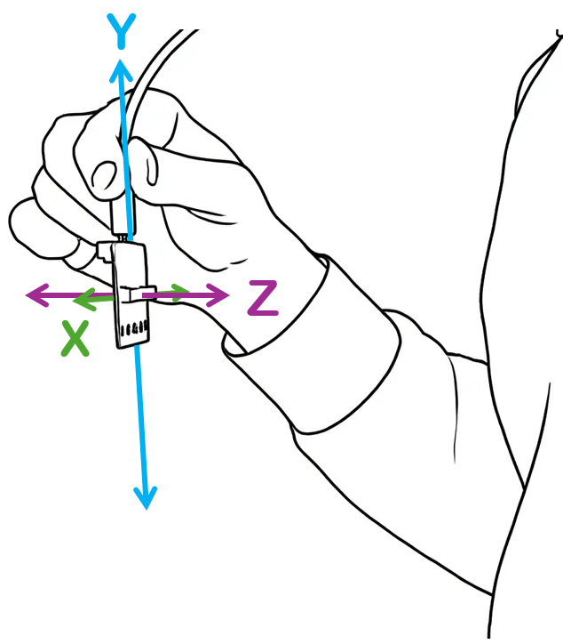

Fig. 3.1: Adjusting micro:bit’s orientation to maximise changes in acceleration along the Y‑axis.

To test the sensor, the user **jumps six times** while holding the micro:bit as depicted in Fig. 3.1. More specifically, the user **rests briefly between each of the first three jumps**, then performs the next **three jumps without resting**. The accelerometer readings, which have been saved in the data file `MY_DATA.HTM`, can be displayed in a web browser and visualised as a function of time after clicking the “Visual Preview” button on the web page, as shown in Fig. 3.2.

[figure not shown]

Fig. 3.2: Visual preview of accelerometer data along the X, Y, and Z axes, sampled every 0.02 seconds.

As can be seen in Fig. 3.2, the measurements along the Y axis taken **before the first jump** provide a baseline from which the sensor’s acceleration can be determined when the micro:bit is **stationary**. If this baseline value, which represents the mean (average), is subtracted from all Y-axis measurements (in Excel, Calc or Numbers), the plot will be centred around zero, as illustrated in Fig. 3.3. The data transformation technique of subtracting the mean of a variable from all measurements is called *mean centering*.

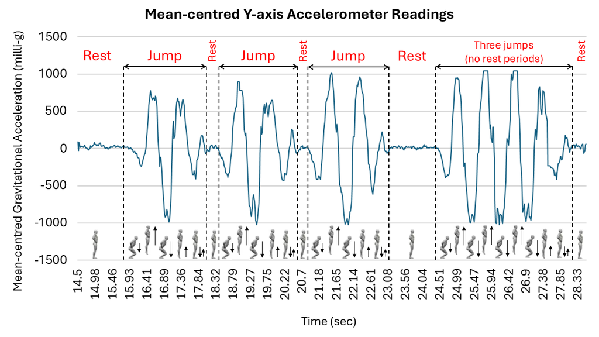

Fig. 3.3: Mean centering of the Y-axis measurements presented in Fig. 3.2. The value of the subtracted mean in this example is 1025 milli-g. Analysis of this plot can reveal movement patterns associated with each jump.

The plot in Fig. 3.3 captures the user’s individual ‘jump profile’, which can vary from person to person. Peaks and troughs in the curve, i.e., local maxima and local minima, separated by zero crossings represent trends and trend reversals in movement, which synthesise each jump. Observe that **different jump types** in Fig. 3.3, e.g., jumps with rest intervals in between or continuous jumps, generate **different ‘signatures’** in the accelerometer readings.

> 📣 **Key takeaway:** Careful examination of a person’s jump profile will identify characteristic patterns for each jump type, which will guide the design of an algorithm in C/C++ that will enable the micro:bit to estimate the number of jumps in real time from accelerometer data.

### Obtain and Analyse your own Jump Profile

Your task for Phase 1 of this project is to develop C code for the micro:bit that stores accelerometer readings into a log file. You should then collect accelerometer measurements while you perform different types of jumps, analyse the recorded data in a spreadsheet application to identify motion patterns, and understand the characteristics of your jump profile.

1️⃣ Implement event listeners and event handlers in `main.cpp` for **Button A**, **Button B**, and the **accelerometer** on board the micro:bit. Each click of **Button A** should toggle the recording state between *enabled* (1) and *disabled* (0). A click of **Button B** should clear the contents of the log file. New **accelerometer** readings should be logged if recording is enabled.

2️⃣ Compile the C source file and transfer `MICROBIT.hex` to your micro:bit. Design a short routine featuring **at least two types of jumps**. Press **Button A** to enable recording, stand still for a couple of seconds and then perform the routine while holding the micro:bit as in Fig. 3.1. After completing the routine, press **Button A** to stop recording. If you want to repeat the routine and reset the log file, press **Button B**.

💡Links to relevant SCC.131 material:

- Event listeners and handlers for buttons A and B: [Lecture notes on Sensors and Logging](https://modules.lancaster.ac.uk/pluginfile.php/4187400/mod_label/intro/SCC131-Week08-Lecture01.pdf?time=1762270218835) | [API](https://lancaster-university.github.io/microbit-docs/ubit/button/)
- Event listeners and handlers for the accelerometer: [API](https://lancaster-university.github.io/microbit-docs/ubit/accelerometer/)
- Logging with micro:bit: [Lecture notes on Sensors and Logging](https://modules.lancaster.ac.uk/pluginfile.php/4187400/mod_label/intro/SCC131-Week08-Lecture01.pdf?time=1762270218835) | [DOCS v2 by c272](https://microbit.c272.org/guides/logging/)
- Online download tool for HEX files if dragging and dropping `MICROBIT.hex` on to the MICROBIT drive does not work: [micro:bit hex download tool](https://microbit.org/tools/webusb-hex-download-tool/)

⚠️ **You should not use the built-in GESTURE events and GESTURE methods of the accelerometer class.** Focus on the processing of raw accelerometer data using the `getX()`, `getY()` and `getZ()` methods.

## Phase 2: Development and Testing

Phase 2 of the project proceeds on the assumption that you have a clear understanding of **what qualifies as a jump of a particular type in the accelerometer data**, which was the objective of Step 3 of Phase 1.

For Phase 2, you are expected to develop code for the micro:bit that collects accelerometer readings as before, but rather than writing them to a data file, your program should process the data in real time and display on the 5×5 LED screen an **up arrow** or **down arrow** when **upward** or **downward** movement is detected.

Using Fig. 3.3 as a reference, **upward movement** is defined as the transition from negative mean-centred values to positive mean-centred values. This event is referred to as a **zero up-crossing**. On the other hand, **downward movement** implies a **zero down-crossing**, i.e., a transition from positive mean-centred values to negative mean-centred values.

The task can be divided into two steps:

1️⃣ Use knowledge gained from SCC.111-Software Development to **write a program in standard C/C++** (i.e., include standard libraries instead of `MicroBit.h`) **that runs on a lab computer and reads the CSV file produced in Step 2 of Phase 1**. Create a function that treats every line of the file as a new accelerometer reading, isolates the Y-axis measurement, subtracts the mean from the measurement, compares the result with previously stored mean-centred measurements, and determines if a zero up-crossing or a zero down-crossing has occurred. Depending on the event that has been detected, the function should print the message “Upward movement” or “Downward movement” on the lab monitor, along with the timestamp or the index of the measurement at which the event was detected. Test your code to verify that the printed messages accurately reflect the transitions displayed in the plot produced in Step 3 of Phase 1.

2️⃣ When you are satisfied that your C/C++ code reliably identifies upward and downward motion in acceleration data stored in a file, shift your focus to **writing C/C++ code that will enable the micro:bit to detect upward and downward motion in real time**. Integrate the function that you developed in the previous step into `main.cpp`. Instead of printing messages on an external monitor, the function should display an up arrow (↑) or a down arrow (↓) on the 5×5 LED screen of the micro:bit when upward or downward movement is detected. If neither upward nor downward movement is detected, the LED screen should be cleared. Compile your source code, transfer `MICROBIT.hex` to your micro:bit device and test it.

> 📣 **Sensitivity to micro-movements:** Your code should be detecting even subtle motions, which could be causing the direction of the arrow on the LED display to constantly change. To see this in action, [watch this short video](https://estream.lancaster.ac.uk/View.aspx?id=94937~5t~O4DpRBCI6C). When counting jumps, micro-movements should be treated as ‘noise’ and ignored. This is the objective of the next development phase.

💡Links to relevant SCC.131 material:

- Displaying images and controlling the 5×5 LED screen of the micro:bit: [Lecture notes on Using the Display](https://modules.lancaster.ac.uk/pluginfile.php/4187400/mod_label/intro/SCC131-Week07-Lecture02.pdf?time=1762431017459) | [API](https://lancaster-university.github.io/microbit-docs/ubit/display/)
- Online download tool for HEX files if dragging and dropping `MICROBIT.hex` on to the MICROBIT drive does not work: [micro:bit hex download tool](https://microbit.org/tools/webusb-hex-download-tool/)

## Phase 3: Refinement and Calibration

**The next two phases are more challenging and more creative, but call for greater initiative and independent decision‑making on your part.**

As in Phase 2, you are encouraged to refine the code you developed in standard C/C++ using the accelerometer data in the CSV file as input. When you are satisfied that you code can accurately estimate the number of jumps in the CSV file, transfer the relevant functions to `main.cpp`, upload the updated `MICROBIT.hex` to your micro:bit device and test your code in practice. Calibrate the logic in your counting method to minimise or eliminate overcounting or undercounting of jumps. Aim for a relative error of 25% or smaller, i.e., if you jump 40 times, the reported jump count should be between 30 and 50.

The task of Phase 3 can be divided into three steps:

1️⃣ **Filter out micro-movements:** Instead of handling ‘raw’ accelerometer data, consider passing the data through a [Simple Moving Average (SMA) filter](https://towardsdatascience.com/time-series-from-scratch-moving-averages-ma-theory-and-implementation-a01b97b60a18/), which is commonly used to smooth out short-term fluctuations (noise) and identify trends in a **time series**, i.e., a sequence of data points plotted over time. The SMA filter uses a **sliding window of size N***, which moves over the accelerometer data. For every time step* j*, the SMA filter calculates the mean of the last* N* accelerometer values, i.e., from *j*-*N*+1 to *j*, and assigns the mean to a new data point at position *j*. For example, for a sliding window of size *N*=3, the value of the data point at time step *j*=10 will be the average of the mean-centred accelerometer readings at time steps 8, 9 and 10.

- Use knowledge gained in SCC.121-Fundamentals of Computer Science to represent a **sliding window of size *N*** as an integer array of *N* elements, where a new element pushes the oldest element out in accordance with the First‑In First‑Out (FIFO) principle.
- Develop a function in ARM Assembly (inline or external) that **returns the average of the *N* values in the sliding window**. For testing purposes, this function could be initially written in C/C++ and then converted into ARM Assembly.

2️⃣ **Focus only on major changes in acceleration:** A jump triggers a pattern of alternating small and large fluctuations in acceleration. We use the term **transition magnitude** to describe the absolute difference between two consecutive local extrema of opposite type, e.g., a local minimum and a local maxmimum, separated by a zero crossing. Major transitions are characterised by a large magnitude, whereas minor transitions are characterised by a small magnitude. Revisit the analysis of your personal jump profile (obtained in Step 3 of Phase 1) to **determine a threshold *θ*** above which a transition is classified as major; transitions falling below this threshold are minor and will be ignored.

3️⃣ **Translate patterns of major acceleration changes into jumps:** Based on your personal jump profile, decide on the values of *N* (size of sliding window) and *θ* (threshold for the magnitude magnitude) and define each type of jump as a sequence of major upward and/or downward transitions. You may not need to consider both upward and downward trasitions but you may have to take into accout the time interval between transitions. For example, the first three jumps in Fig. 3.3 are all characterised by two major downward transitions followed by a short period of inactivity. Display the number of jumps on the LED screen of the micro:bit and introduce additional features that give users the option to pause, restart and reset the counter, enable/disable data logging and clear the log file. For an example of the jump counter in operation, [watch this short video](https://estream.lancaster.ac.uk/View.aspx?id=94954~5s~mgnNgqrozK).

## Phase 4: User Experience

Hardware and low‑level software in smart devices are essential but tend to feel more abstract or inaccessible to the average user. For this reason, users often take them for granted and gravitate toward front‑end software because this is the part of the echnology they can see and interact with. Front-end software shapes user experience.

**Your task for Phase 4 is to develop a software app for the lab computers that improves the jump counter’s user experience. You can use C, C++ or Java for code development. Don’t forget to choose a cool name for your app.**

The minimum requirement for the app is to read the downloaded CSV file and output in text form at least two useful metrics in addition to the estimated total number of jumps. For example, the app could report peak-exertion intervals and the highest number of consecutive jumps.

Students who wish to push their limits could develop an app that reads the accelerometer data directly from the log file `MY_DATA.HTM`, plots activity information in a graphical interface and reports at least three useful metrics in addition to the estimated total number of jumps.

## Marking Scheme

Marks will be awarded according to the marking scheme shown at the start of this document. Marks for the ‘Functionality’ section will be awarded based on individual merit, but the following table gives an **indicative** overview of the level of functionality expected for each grade band:

**A**

**B**

All objectives for grade C have been met, plus:

- Code in C/C++ that implements a Simple Moving Average (SMA) filter and calls an averaging function that has been written in ARM Assembly (Step 1 of Phase 3).
- Working C/C++ program that runs on a micro:bit device, employs both an SMA filter and thresholding to count jumps in real time, and achieves a relative error that is higher than 10% but lower than or equal to 25% (Step 2 and first part of Step 3 of Phase 3).
- Additional features that enable the micro:bit to control the jump counter and record data to `MY_DATA.HTM` (Last part of Step 3 of Phase 3).

**C**

All objectives for grade D have been met, plus:

- Working C/C++ program that runs on a lab computer, reads CSV files that contain accelerometer readings, and idenities upward and downward motion in accelerometer data (Step 1 of Phase 2).
- Working C/C++ program that runs on a micro:bit device, detects upward and downward motion in real time, and displays an up arrow or a down arrow, respectively (Step 2 of Phase 2).

**D**

The following objectives have been met:

- Working C/C++ program for the micro:bit that collects accelerometer readings and stores them in the default log file `MY_DATA.HTM` has been developed and demonstrated (Steps 1, 2 of Phase 1).
- Accelerometer readings for a jumping routine have been exported in a CSV file and analysed in a spreadsheet application, and key characteristics of different types of jumps have been determined (Step 3 of Phase 1).

**F**

No working code was demonstrated, or the code did not meet any of the above project objectives.

## Star Award

Students who meet all project objectives for an A will receive a *Star Award* for ‘Functionality’ (i.e., full marks). A *Star Award* (i.e., bonus marks) is also available for students who do not meet all project objectives but their jump counter achieves **a relative error of 10% or lower**.